# Part 8: Monte Carlo Simulations

E. Exercises

Mingyang Lu

08/22/2023

# 1. Sampling a mixture of bivariate Gaussian distributions

We wish to simulate a set of flow cytometry data for a mixture of cells with two distinct cellular states. Let’s consider the following 2D distribution (not normalized) $p(x, y)$, consisting of two bivariate Gaussian distributions. $x$ and $y$ measure the expression levels of two proteins for individual cells.

$$p(x,y) = e^{-(x + 10y - 1)^2 - (x - 0.1y
+ 2)^2} + e^{-(x - 5y + 2)^2 - (x + 0.2y - 1)^2}. \tag{1}$$

The following R function *p_mixture* computes $p(x,y)$ (the variables $x$ and $y$ are inputted in a vector of size 2).

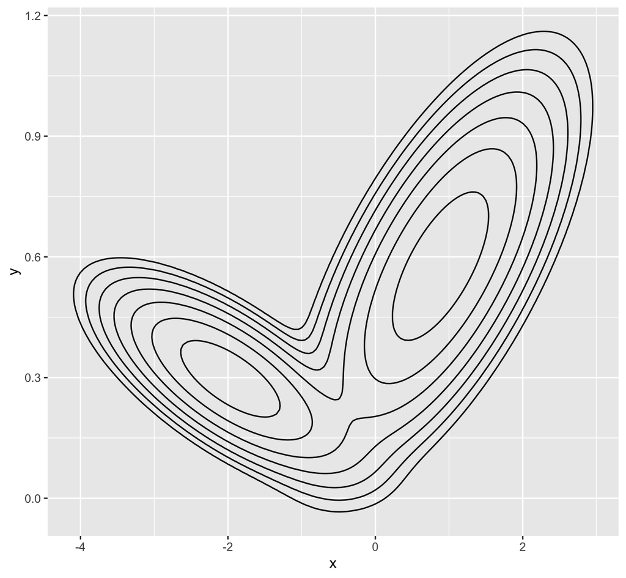

```r
library(ggplot2)
p_mixture <- function(x){
  f1 = x[1]+10*x[2]-1
  f2 = x[1]-0.1*x[2]+2
  f3 = x[1]-5*x[2] + 2
  f4 = x[1]+0.2*x[2] - 1
  return(exp(-f1**2-f2**2) + exp(-f3**2-f4**2))
}

x_all = seq(-5,5, by =0.05)
y_all = seq(-2,2, by =0.01)
data = expand.grid(x_all, y_all)
colnames(data) = c("x", "y")
z_all = apply(data, MARGIN = 1, p_mixture)
data$z = z_all
ggplot(data, aes(x=x, y=y, z = z)) + geom_contour(breaks = 10^(seq(-2,0, by =0.3)), colour = "black")
```

Design a Metropolis-Hastings algorithm to sample the distribution. Show your simulation results by plotting the density map of the sampled data points.

Hint:

1. Think how to devise an appropriate local move to sample $x$ and $y$.
2. You can use *geom_bin2d* from the ggplot2 library to plot the density map.

# 2. 2D Ising Model

The Ising model describes a system of interacting spins on a lattice. Consider an $N \times N$ square lattice with periodic boundary conditions, where each site $i$ has a spin $s_i \in \{-1, +1\}$. The energy function of the system is given by:

$$\begin{equation}
E = -J \sum_{\langle i,j \rangle} s_i s_j,
\end{equation}$$

where the sum runs over all pairs of nearest-neighbor spins, and $J$ is the interaction strength (assume $J=1$ for simplicity).

**(a)** Implement the Metropolis algorithm by sampling the Boltzmann distribution of the system:

$$P \sim e^{-E/T}$$
The proposal move flips a randomly selected spin. Make sure to consider the periodic boundary condition. The initial condition is chosen to be a lattice with random spins $s_i = \pm 1$. We consider $N = 20$. Check NumericalR Part 8B for an example of MCMC modeling of the Ising model in 1D.

**(b)** Now we compute the magnetization per spin.

$$M = \frac{1}{N^2} \sum_{i}
s_i$$

Perform MCMC sampling for a small number of iterations ($\sim 10^4$) at temperature $T = 1.5$. Plot the total energy and the average magnetization $\langle |M| \rangle$ (absolute value) as a function of number of steps. Once you find the results make sense, run the MCMC sampling again for much longer simulations ($\sim 10^6$) to estimate the relaxation time for the system to reach a steady behavior.

**(c)**. To study the phase transition of the Ising model, we run MCMC sampling at ten different temperatures $T \in [1.5, 3.5]$. Compute the average magnetization $\langle |M| \rangle$ over long Monte Carlo simulations (remember to only perform the statistical analysis on the later steps where the system has reached to the steady behavior). Plot $\langle |M| \rangle$ as a function of temperature and identify the critical temperature $T_c$ where there is a sharp drop in magnetization.

Compare your estimated $T_c$ with the theoretical value for an infinite system:
$$T_c = \frac{2J}{\ln(1+\sqrt{2})} \approx
2.269$$

# 3. Stochastic SIR model.

Consider the following reaction network:

$$S + I {\stackrel{\beta}{\rightarrow}}
2I$$

$$I {\stackrel{\nu}{\rightarrow}} R$$

where $\beta = 0.003$ and $\nu = 1$.

**(a)** We consider the initial condition $S(t=0) = 1000$, $I(t=0) = 1$, and $R(t=0) = 0$. Compute $R_0$. Perform a Gillespie simulation and plot the time dynamics of $S$, $I$ and $R$. Please read the “Gillespie_tutorial.rmd” R Markdown for other modeling examples. You can directly use the functions *gillespie_step* and *ssa*, and you will need to write your own propensity function and stoichiometry function in the following format:

```r
my_propensity <- function(Xs) {   # Xs: current state; you can also supply parameters

  #output: a vector of propensity for all reactions
}

my_stoichiometry <- function(r_ind) {   # r_ind: the choice of the reaction

  # output: the stoichiometry vector for the reaction r_ind
}
```

**(b)** Perform a deterministic simulation of the same model (check the course PPTs for modeling epidemiology). Visually compare the deterministic and stochastic dynamics. For ODE integration, you can use the following RK4 function

```r
RK4_generic <- function(derivs, X0, n, t.total, dt, ...){ # Runge-Kutta 4th order, n variables, passing parameters via ellipsis
  # derivs: the function of the derivatives
  # X0: initial condition, a vector of two elements
  # n: total number of variables
  # t.total: total simulation time, assuming t starts from 0 at the beginning
  # dt: time step size
  t_all = seq(0, t.total, by=dt)
  n_all = length(t_all)
  X_all = matrix(0, nrow = n_all, ncol = n)
  X_all[1,] = X0
  for (i in 1:(n_all-1)) {
    t_0= t_all[i]
    t_0.5 = t_0 + 0.5*dt
    t_1 = t_0 + dt
    k1 = dt * derivs(t_0,X_all[i,], ...)
    k2 = dt * derivs(t_0.5,X_all[i,] + k1/2, ...)
    k3 = dt * derivs(t_0.5,X_all[i,] + k2/2, ...)
    k4 = dt * derivs(t_1,X_all[i,] + k3, ...)
    X_all[i+1,] = X_all[i,] + (k1+2*k2+2*k3+k4)/6
  }
  return(cbind(t_all, X_all))   # the output is a matrix of t & X(t) for all time steps
}
```

**(c)** Now we consider another set of parameters $\beta = 0.3$ and $\nu = 1$, and a new initial condition $S(t=0) = 10$, $I(t=0) = 1$, and $R(t=0) = 0$. You will find the same $R_0$ under this condition, thus similar deterministic dynamics. Perform the Gillespie simulation (try stochastic simulations multiple times, each with different random number seeds) and deterministic simulations again. Compare your results.

If you try a sufficient large number of simulations, you will find a variety of SIR dynamics:

**(1)** dynamics similar to the deterministic dynamics: with a peak in $I(t)$, no $I$ eventually, but with positive $S$.

**(2)** $I(t)$ dies out at the very beginning;

**(3)** $I(t)$ generates a peak, but $I(t)$ dies out earlier and there are a sufficiently large number of $S$ left.

**(4)** $I(t)$ generates a peak, but eventually there is no $S$ and $I$ left.

# 4. Stochastic toggle switch model.

We model a toggle switch of two genes $X$ and $Y$, mutually inhibiting each other. Consider the following reaction network:

$$D_x {\stackrel{g}{\rightarrow}}D_x +
X$$
$$D_y
{\stackrel{g}{\rightarrow}}D_y + Y$$

$$X
{\stackrel{k}{\rightarrow}}\varnothing$$
$$Y
{\stackrel{k}{\rightarrow}}\varnothing$$

$$D_x + 2Y
\underset{k_{-1}}{\stackrel{k_1}{\rightleftharpoons}} C_x
\tag{2}$$

$$D_y + 2X
\underset{k_{-1}}{\stackrel{k_1}{\rightleftharpoons}} C_y
\tag{3}$$
, where $g$, $k$, $k_1$, $k_{-1}$ are four kinetic parameters. $D_x + C_x = 1$, and $D_y + C_y = 1$.

**(a)** Consider fast binding and unbinding rates for transcription factor and DNA interactions, show that the deterministic model of the system can be written as

$$\begin{equation}
\begin{cases} \frac{dX}{dt} = \frac{g}{1+\frac{Y^2}{Y_0^2}} - k X\\
\frac{dY}{dt} = \frac{g}{1+\frac{X^2}{X_0^2}} - k Y
\end{cases}
\end{equation}$$

, where $X_0 = Y_0 = \sqrt{\frac{2k_{-1}}{k_1}}$.

Hint: the reaction rate for the forward reaction in Equation (2) is $\frac{1}{2}k_1D_xY^2$. We also consider that the forward and the backward reaction rates are balanced due to quasi-steady-state approximation:

$$\frac{1}{2}k_1D_xY^2 =
k_{-1}C_x$$
You will obtain a similar expression from Equation (3).

**(b)** Show that the toggle switch circuit is bistable under the deterministic regime. Here, $g = 40$, $k=0.1$, $k_1 = 0.00001$, and $k_{-1} = 0.2$. (Please double check! This is monostable)

Hint: to show the system is bistable, you can pick at least two initial conditions of $X$ and $Y$ and show with ODE simulations that the system reaches to two different stable steady states.

**(c)** Perform stochastic simulation using Gillespie algorithm. Use the same kinetic parameters and for the initial condition, use $D_x = 1$, $C_x = 0$, $D_y = 0$, $C_y = 1$, $X = 300$, $Y = 200$. Run the simulation for a total of 1000 unit time. Plot the time dynamics of $X$ and $Y$. You are supposed to observe stochastic state transitions.

Please read NumericalR R Markdown for other modeling examples. You can directly use the functions *gillespie_step* and *ssa*, and you will need to write your own propensity function and stoichiometry function in the following format:

```r
my_propensity <- function(Xs) {   # Xs: current state; you can also supply parameters

  #output: a vector of propensity for all reactions
}

my_stoichiometry <- function(r_ind) {   # r_ind: the choice of the reaction

  # output: the stoichiometry vector for the reaction r_ind
}
```